# Reproducible Research: Peer Assessment 1

## Setting Global Options

```r
knitr::opts_chunk$set(echo = TRUE, results = "asis", warning = TRUE, message = TRUE)
```

## Loading R packages

```r
library(xtable)
library(ggplot2)
library(lattice)
```

## Loading and preprocessing the data

### 1. Load the data (i.e. read.csv())

##### Unzip the file

```r
zipDataFile <- "activity.zip"
dataFile <- "activity.csv"
if(!file.exists(dataFile)){
    unzip(zipDataFile)
}
```

##### Read and load the data

```r
workingDirectory <- getwd()
initial <- read.table(file.path(workingDirectory,
        dataFile),
        header = TRUE,
        sep = ",",
        nrow = 1000)

classes <- sapply(initial, class)

fullData <- read.table(file.path(workingDirectory,
            dataFile),
            header = TRUE,
            sep = ",",
            na.strings="NA",
            colClasses  = classes,
            comment.char = "#",
            stringsAsFactors=FALSE)

rm(initial)
```

##### A first look at the data ..

|  | steps | date | interval |
| --- | --- | --- | --- |
| 1 |  | 2012-10-01 | 0 |
| 2 |  | 2012-10-01 | 5 |
| 3 |  | 2012-10-01 | 10 |
| 4 |  | 2012-10-01 | 15 |
| 5 |  | 2012-10-01 | 20 |
| 6 |  | 2012-10-01 | 25 |
| 7 |  | 2012-10-01 | 30 |
| 8 |  | 2012-10-01 | 35 |
| 9 |  | 2012-10-01 | 40 |
| 10 |  | 2012-10-01 | 45 |

### 2. Process/transform the data (if necessary) into a format suitable for your analysis

##### Change the date variable from factor to date format. Delete rows with missing values saving the data in a new dataframe. NB: the original dataframe is kept for further use later

```r
fullData$date <- as.Date(fullData$date)
cleanData <- subset(fullData, !is.na(fullData$steps))
```

## What is mean total number of steps taken per day?

### 1. Make a histogram of the total number of steps taken each day

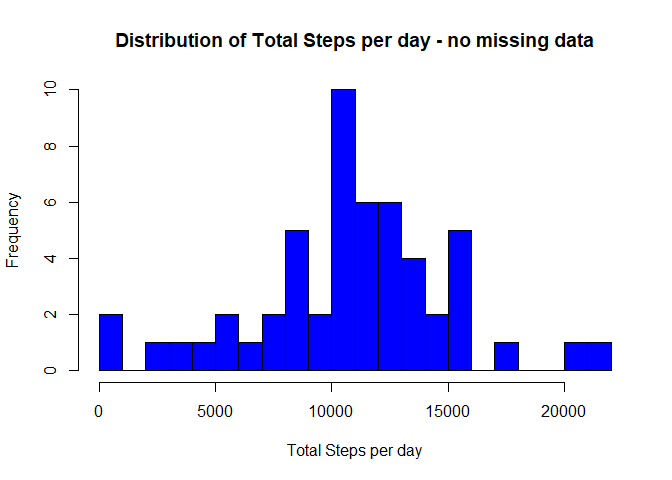

```r
totalStepsByDay <- tapply(cleanData$steps, cleanData$date, sum)
hist(totalStepsByDay,
     col="blue",
     breaks=20,
     xlab="Total Steps per day",
     ylab="Frequency",
     main="Distribution of Total Steps per day - no missing data")
```

### 2. Calculate and report the mean and median total number of steps taken per day

```r
mean(totalStepsByDay)
```

[1] 10766.19

```r
median(totalStepsByDay)
```

[1] 10765

## What is the average daily activity pattern?

### 1. Make a time series plot (i.e. type = “l”) of the 5-minute interval (x-axis) and the average number of steps taken, averaged across all days (y-axis)

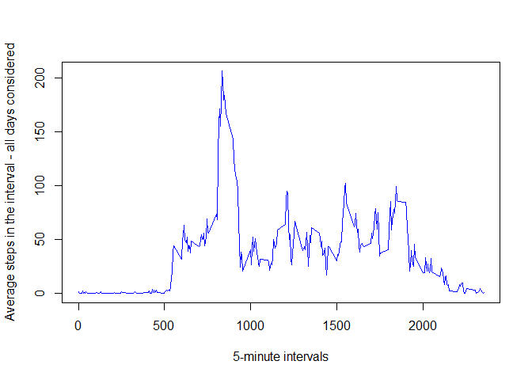

```r
intervalAverage <- tapply(cleanData$steps, cleanData$interval, mean)
intervalAverageDF <- data.frame(interval=as.integer(names(intervalAverage)), averageSteps=intervalAverage)

with(intervalAverageDF,
     plot(interval,
          averageSteps,
          type="l",
          col = "blue",
          xlab="5-minute intervals",
          ylab="Average steps in the interval - all days considered"))
```

### 2. Which 5-minute interval, on average across all the days in the dataset, contains the maximum number of steps?

```r
maxAverageSteps <- max(intervalAverageDF$averageSteps)
intervalAverageDF[intervalAverageDF$averageSteps == maxAverageSteps, ]
```

```
interval averageSteps
```

835 835 206.1698